# Causal Inference Methods for Policy Evaluation

00-Introduction

Jacopo Mazza

Utrecht School of Economics

2026

Introductions

## About me

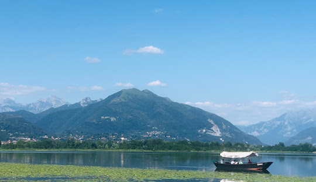

[figure not shown]

[figure not shown]

[figure not shown]

[figure not shown]

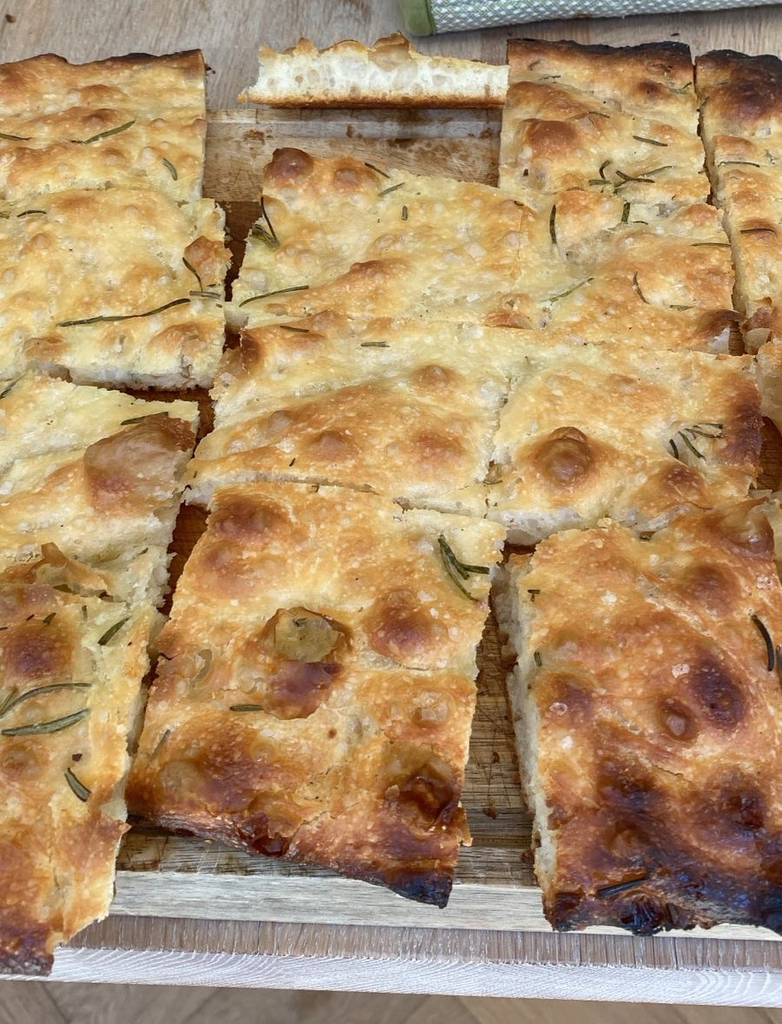

## About you

- Name
- Where are you from?
- What is your background?
- One other thing about you

Course Outline

## Assumed Background

What I will not assume:

- Prior knowledge of causal inference

What I will assume:

- Basic knowledge of statistics:
  - Hypothesis testing
  - Regression analysis
  - Basic probability theory
  - Basic calculus
- Basic knowledge of econometrics:
  - OLS
- Some knowledge of R

## Learning Outcomes

1. Develop identification strategies to uncover causal effects for a given research question and in a given context.
2. Applying state-of-the-art causal inference techniques using real-world data and statistical software.
3. Critically evaluate the assumptions and limitations of various causal inference methods.
4. Apply visualization techniques and effectively communicate and interpret research findings.

## Textbook and computing

[figure not shown]

- Cunningham, Scott. *Causal Inference: The Mixtape*. Yale University Press, 2021. https://doi.org/10.2307/j.ctv1c29t27.
- Also available in a free html version at https://mixtape.scunning.com/

## Format

- Monday 1:30 hours of lecture (13:15–15:00) – BBG 219
- Tuesday 1:30 hours of lab (09:00–1-:45) – DALTON 500 - 8.27
  - **Tutorial week 13 (24th of March) on Tuesday in DALTON 500 -6.27**

## Instructors

[Jacopo Mazza, PhD](https://jacopoto.github.io/)  
Utrecht University  
School of Economics  
Adam Smith Building 112.A  
Email: j.mazza@uu.nl

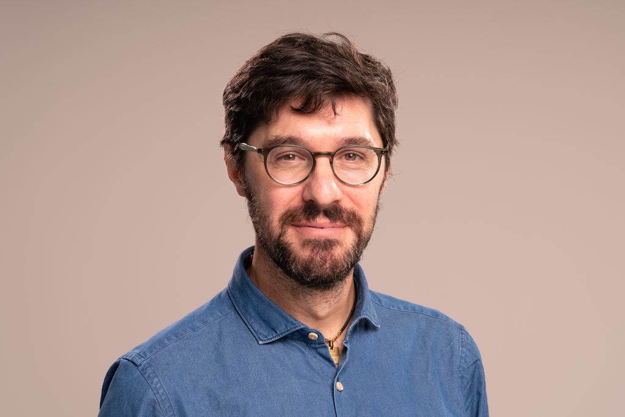

[Sönke Matthewes, PhD](https://sites.google.com/view/sonkematthewes/home)  
Utrecht University  
School of Economics  
Adam Smith Building 112.A  
Email: s.h.matthewes@uu.nl

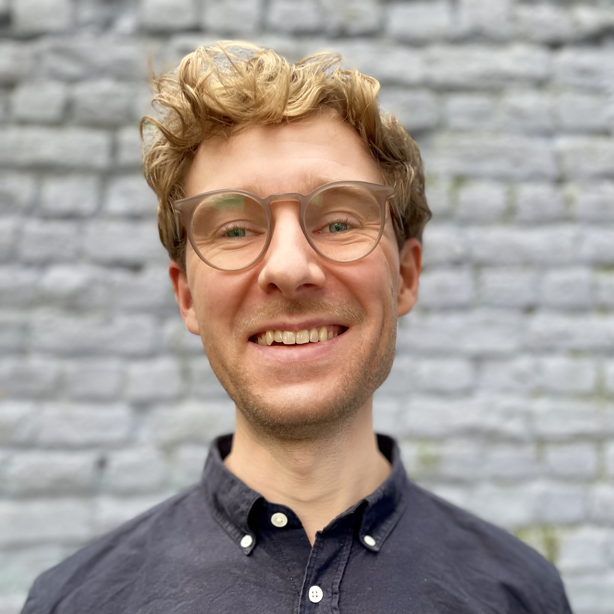

## Assessment

- Week 10: Midterm exam (50%).
  - March 2nd. 13:30-15:30. EDUC - BETA
- Week 15: Final exam (50%)
  - April 7th. 13:30-15:30. EDUC - GAMMA

Format: 3 questions, 2:00 hours.

## Tentative Schedule

[output not shown]

## Course Policy

- Attendance is not mandatory, but highly recommended.
- Electronic devices are not allowed<sup>1</sup>:
- We have good evidence that they hurt your learning.

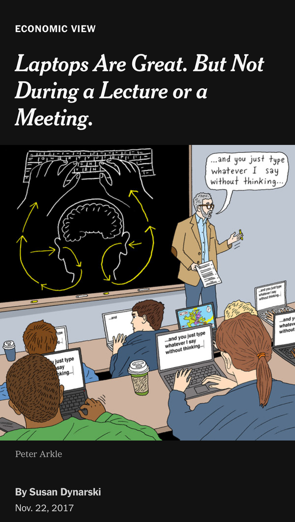

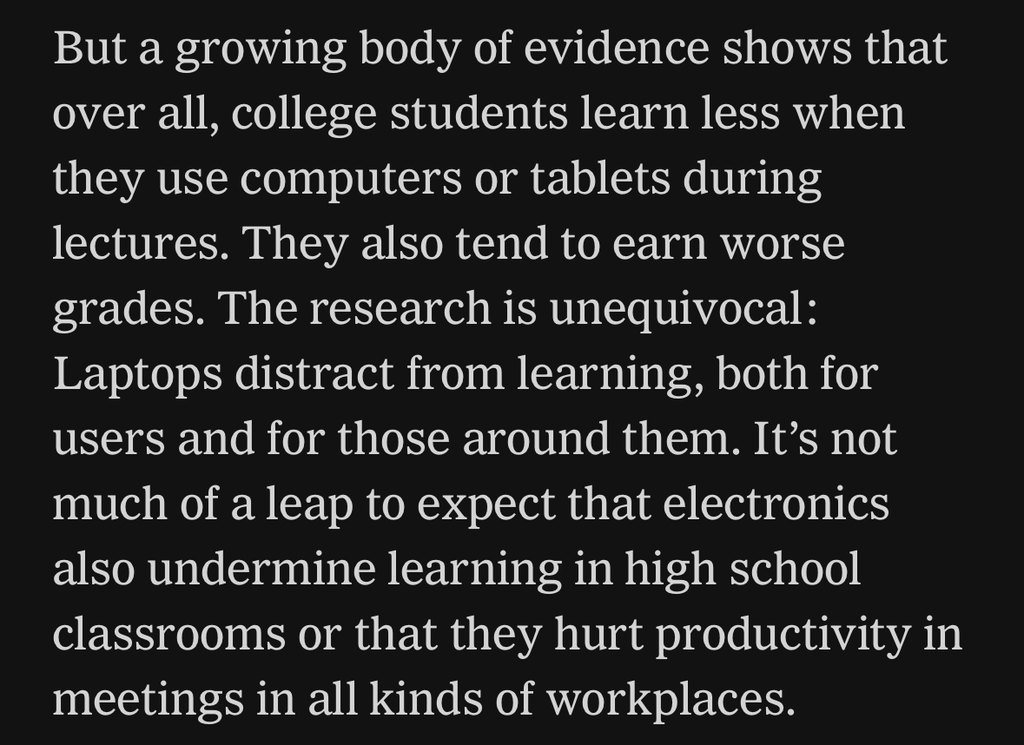

[figure not shown]

[^1]: Please contact me if you have a special need